# Programação para Cientistas Sociais

06/09/2017

## Operadores Lógicos (I)

- Mais: +
- Menos: -
- Multiplicação: *
- Divisão: /
- Diferente: !
- Menor: <
- Maior: >
- Menor/igual: <=
- Maior/igual: >=

## Operadores Lógicos (II)

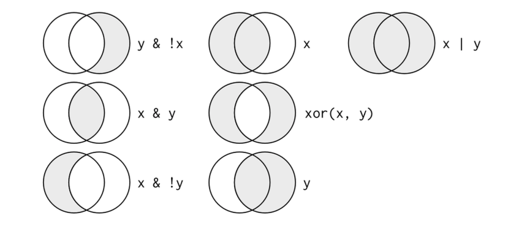

Wickham, 2017:47

## Ambiente *Tidyverse*

Pacote guarda-chuva que abriga:

- dplyr (mexer nos dados)
- readr (importar dados)
- ggplot2 (gráficos)
- tidyr (facilitar mudança de *wide* para *long*)
- purrr (substituto dos *loops*)
- tibble (construir próprios dados)
- Foco: "dplyr", "readr"

## Operadores Principais do *dplyr*

6 verbos:

- rename() # renomear variáveis
- select() # selecionar variáveis, colunas
- filter() # filtrar linhas
- summarise() # tirar médias, medianas, desvio-padrão, etc.
- group_by() # agrupar valores das colunas
- arrange() # ordenar os dados

## Principais comandos do *readr*

- read_csv() # abrir excel separado por vírgulas
- read_csv2() # abrir excel separado por ponto e vígula

## Comandos do *haven*

Pacote para abrir dados de SPSS, Stata e SAS

- read_sas() # abrir dados do SAS
- read_spss() # abrir dados do SPSS
- read_dat() # abrir dados do Stata

## Comandos do *janitor*

Pacote alternativo para sumarizar dados.

- tabyl() # tabular somente uma variável
- crosstab() # tabular duas variáveis

## Exercício do dia

Ver diferenças de percepções entre católicos e evangélicos sobre a meritocracia.

- Abrir WVS 2014.
- Separar variáveis V144 (denominação religiosa) e V100 (*hard work brings success*).
- Renomear "V144" para "religiao" e "V100" para "meritocracia".
- Tricotomizar a variável meritocracia ("favor", "meio", "contra").
- Mudar os valores "25" e "64" da variável "religiao" para "evangelicos" e "catolicos", respectivamente.
- Tabular cada uma das duas.
- Cruzar as duas variáveis.
- Salvar em ".csv".